# UNIT05A：機率概論

中山大學管理學院 卓雍然

2021-03-22 16:19:52

```r
pacman::p_load(magrittr)
```

### 【A】以(欄位)向量為基礎的『隨機變數』

💡： **隨機實驗**：重複進行時會出現不能完全預測的結果的實驗。

💡： **隨機變數**：定義在隨機實驗的結果之上的變數。

##### 在向量上定義隨機變數

產生一個長度為10的類別向量(`SkinColor`)

```r
SkinColor = c("白","白","白","白","紅","紅","紅","黃","黃","黑")
```

向量本身並不是隨機變數，但是 …  
💡：我們可以用 「從向量中隨機抽取一個值」這一個「隨機實驗」來定義一個「隨機變數」。

##### 隨機抽樣

隨機抽出一個長度為20點的結果向量(`x`)

```r
x = sample(SkinColor, size=20, replace=T); x
```

```
 [1] "白" "紅" "黃" "黃" "紅" "紅" "黃" "白" "白" "白" "黑" "白" "白" "紅" "白"
[16] "白" "紅" "白" "白" "紅"
```

##### 分佈：(隨機)變數的『值』所出現的『頻率』

分佈有兩種表示方式：頻率(次數)、比率(機率)

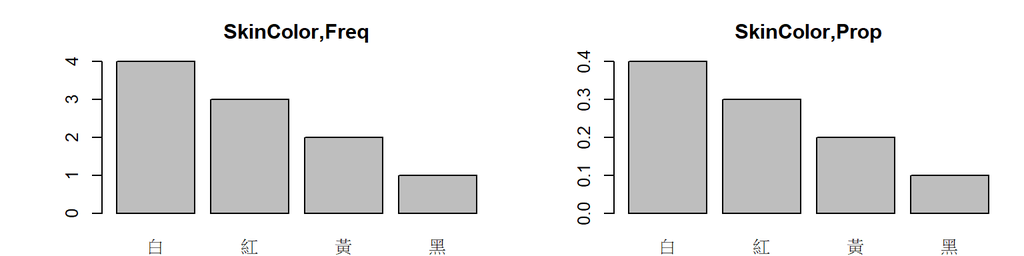

```r
par(mfrow=c(1,2), mar=c(2,5,3,1), cex=0.8)
table(SkinColor) %>% barplot(main='SkinColor,Freq')
table(SkinColor) %>% prop.table %>% barplot(main='SkinColor,Prop')
```

##### 結果向量的分佈

隨機抽樣會產生不同的結果，結果向量之中的分佈可能與原始向量不同

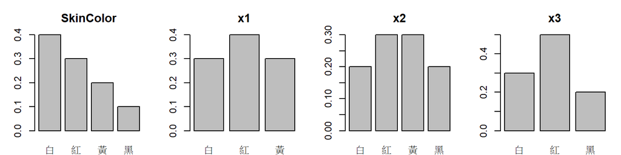

```r
par(mfrow=c(1,4), mar=c(2,3,3,1), cex=0.75)
table(SkinColor) %>% prop.table %>% barplot(main='SkinColor')
table( sample(SkinColor,10,T) ) %>% prop.table %>% barplot(main='x1')
table( sample(SkinColor,10,T) ) %>% prop.table %>% barplot(main='x2')
table( sample(SkinColor,10,T) ) %>% prop.table %>% barplot(main='x3')
```

💡： 結果向量的比率未必能直接代表原始族群的比率！

##### 多項式(Multinomial)分佈的事件機率

$$Multinomial \; 事件機率公式 \; : \;
\frac{n!}{k_1!\,k_2\,...\,k_i!} \; \prod p_i^{k_1} \\
\frac{10!}{4!\,3!\,2!\, 1!} (.4)^4 \, (.3)^3 \, (.2)^2 \, (.1)^1
\; \simeq \; 0.034836$$

```r
dmultinom(c(4,3,2,1), prob=c(0.4,0.3,0.2,0.1))
```

```
[1] 0.034836
```

```r
replicate(1000, identical(
  as.integer(table(sample(SkinColor,10,T))),
  4:1)) %>% table
```

```
.
FALSE  TRUE
  973    27
```

💡： 樣本大小設定為`10`時，抽1000次大概只有35次樣本的比率會等於期望的機率！

##### 如果我們增加抽樣的次數

```r
set.seed(2)
lapply(1:7, function(n) {
  sample(SkinColor,10^n,T) %>% table %>% prop.table
  })
```

```
[[1]]
.
 白  紅  黃
0.5 0.3 0.2

[[2]]
.
  白   紅   黃   黑
0.41 0.34 0.20 0.05

[[3]]
.
   白    紅    黃    黑
0.384 0.308 0.203 0.105

[[4]]
.
    白     紅     黃     黑
0.4028 0.3044 0.1998 0.0930

[[5]]
.
     白      紅      黃      黑
0.40013 0.29942 0.20094 0.09951

[[6]]
.
      白       紅       黃       黑
0.399723 0.300107 0.200425 0.099745

[[7]]
.
     白      紅      黃      黑
0.39996 0.29993 0.20008 0.10003
```

💡： 當抽樣的次數(樣本大小)很大時，結果向量的比率會貼近原始族群的比率！

💡： 樣本中各分類的的比率並不會正好等於它們的期望機率！

💡： 樣本越大，結果向量的實際比率與期望機率之間的誤差越小。

### 【B】用R學統計、有圖有真相

- 抽樣
- 計算比率(機率)
- 重複實驗
- 畫圖
- 畫很多圖

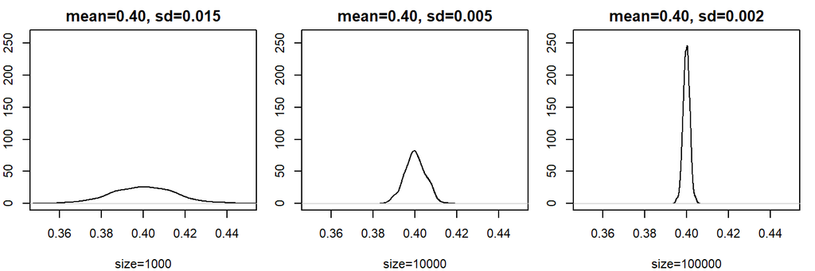

```r
par(mfrow=c(1,3),mar=c(4,2,2,1),cex=0.7)
for(sz in 10^(3:5)) {
  w = replicate(1000, mean(sample(SkinColor,sz,T)=="白"))
  density(w) %>% plot(
    xlim=c(0.35,0.45), ylim=c(0,260), xlab=paste0("size=",sz), ylab="",
    main=sprintf("mean=%.2f, sd=%.3f", mean(w), sd(w))
    )}
```

### 【C】 隨機變數的分類

💡：隨機變數有三種常見的分類方式…

- 離散 vs. 連續
- 類別 vs. 數值
- 實證 vs. 理論

🗿： 常態分佈(Normal Dist.)所描述的是哪一類分佈？

🗿： 二項分佈(Binomial Dist.)所描述的是哪一類分佈？

🗿： 卜瓦松分佈(Poission Dist.)所描述的是哪一類分佈？

🗿： 請舉一個實證分布的例子 …

##### 定義不同「種類」的隨機變數

從常態分佈產生一個長度為100的結果向量：`Weight`

```r
set.seed(2)                         # set.seed for randomization
Weight = rnorm(100,mean=60,sd=5)    # 100 random samples
Weight
```

```
  [1] 55.515 60.924 67.939 54.348 59.599 60.662 63.540 58.802 69.922 59.306
 [11] 62.088 64.909 58.037 54.802 68.911 48.445 64.393 60.179 65.064 62.161
 [21] 70.454 54.000 67.948 69.773 60.025 47.741 62.386 57.017 63.961 61.448
 [31] 63.695 61.595 65.381 58.579 56.117 57.022 51.370 55.487 57.205 58.767
 [41] 58.082 50.204 55.791 69.518 63.112 69.955 58.473 59.546 59.079 54.006
 [51] 55.809 70.332 57.189 66.379 54.762 50.171 58.385 64.679 65.696 68.358
 [61] 51.059 70.156 56.484 60.791 62.531 55.900 50.006 57.604 60.421 55.523
 [71] 55.394 61.652 59.292 62.174 59.731 55.464 66.518 63.859 65.263 52.950
 [81] 64.980 51.521 57.333 53.139 48.960 69.111 56.733 58.577 58.065 61.933
 [91] 68.002 68.406 54.082 53.208 52.437 53.734 69.797 60.038 55.787 56.994
```

##### 連續變數的分佈

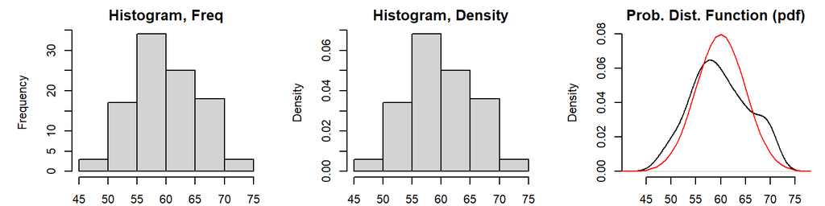

```r
par(mfrow=c(1,3), mar=c(2,5,2,1), cex=0.7, bty='n')
hist(Weight, main='Histogram, Freq')
hist(Weight, main='Histogram, Density', freq=F)
plot(density(Weight),main='Prob. Dist. Function (pdf)',ylim=c(0,0.08))
curve(dnorm(x,60,5),0,100,col='red',add=T)
```

##### 四種不同「種類」的隨機變數

其實隨機變數的「種類」不只兩種

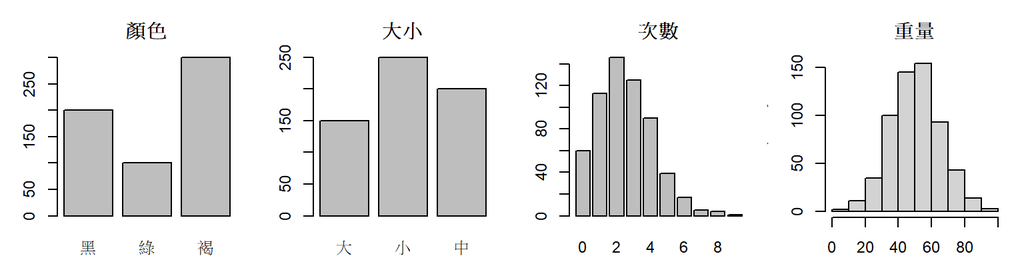

```r
par(mfrow=c(1,4), mar=c(2,3,3,1), cex=0.75)
Color = rep(c('綠','黑','褐'), c(100,200,300)) # categorial, non-order
table(Color) %>% barplot(main="顏色")
Size = rep(c('大','中','小'), c(150,200,250))  # categorial, order
table(Size) %>% barplot(main="大小")
Freq = rpois(600,2.5)                   # numeric, discrete
table(Freq) %>% barplot(main= "次數")
Weight = rnorm(600,50,15)               # numeric, contineous
hist(Weight, main= "重量")
```

🍭 練習：  
以下這一段簡單的程式碼就可以分別畫出「類別」與「數值」變數的「頻率(次數)」與「機率」分佈；你可以在雙引號之間補進正確的標題，如：“類別變數的次數分布”、“頻率”、“機率”、“密度”等等，讓圖形更加完整，更能幫助同學們分辨這四種不同的分佈嗎？

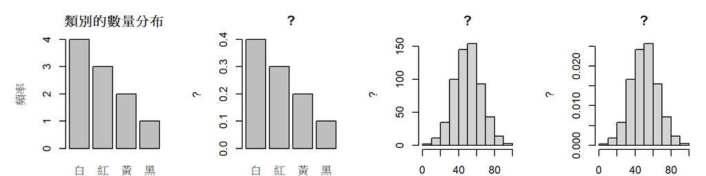

```r
par(mfrow=c(1,4), mar=c(2,5,3,1), cex=0.75)
table(SkinColor) %>% barplot(main="類別的數量分布", ylab="頻率", xlab="SkinColor")
table(SkinColor) %>% prop.table %>% barplot(main="?", ylab="?", xlab="SkinColor")
hist(Weight, main="?", ylab="?")
hist(Weight, freq=F, main="?", ylab="?")
```